# Module 4

WARNING: This chapter is still in draft form.  
Materials for February 28–March 11, 2022.

## Learning checklist

- Recognize a form of the probability density function for Bernoulli, binomial, negative binomial, Poisson, gamma and beta.
- Identify how changing values for a parameter affects the characteristics of the probability distribution.
- Identify the mean and variance for each distribution.
- Match the response for a study to a plausible random variable and provide reasons for ruling out other random variables.
- Match a histogram of sample data to plausible distributions.
- Create tables and calculate joint, marginal and conditional probabilities with them.
- Calculate odds, risks, odds ratios (OR) and risk ratios (RR).
- Understand why ORs and RRs are similar for rare outcomes.
- State the assumptions of GLMs.
- Interpret logistic regression output (more next week!).

## Introduction

.midi[Much of this section should be recap of things you’ve learned in second year statistics courses.

**Reading:** [Chapter 3](https://bookdown.org/roback/bookdown-BeyondMLR/ch-distthry.html) (§ 3.3.1, 3.3.2, 3.3.4, 3.3.6, 3.4.2, 3.5) of Roback, P. & Legler, J. Beyond Multiple Linear Regression. (2021). https://bookdown.org/roback/bookdown-BeyondMLR/.

.pull-left[ ### Sections to read * [3.3 Discrete random variables](https://bookdown.org/roback/bookdown-BeyondMLR/ch-distthry.html#discrete-random-variables) * [3.3.1 Binary Random Variable](https://bookdown.org/roback/bookdown-BeyondMLR/ch-distthry.html#sec-binary) * [3.3.2 Binomial Random Variable](https://bookdown.org/roback/bookdown-BeyondMLR/ch-distthry.html#sec-binomial) * [3.3.4 Negative Binomial Random Variable](https://bookdown.org/roback/bookdown-BeyondMLR/ch-distthry.html#negative-binomial-random-variable) * [3.4 Continuous random variables](https://bookdown.org/roback/bookdown-BeyondMLR/ch-distthry.html#continuous-random-variables) * [3.4.2 Gamma Random Variable](https://bookdown.org/roback/bookdown-BeyondMLR/ch-distthry.html#gamma-random-variable) * [3.4.4 Beta Random Variable](https://bookdown.org/roback/bookdown-BeyondMLR/ch-distthry.html#beta-random-variable)] .pull-right[  
* [3.5 Distributions Used in Testing](https://bookdown.org/roback/bookdown-BeyondMLR/ch-distthry.html#distributions-used-in-testing) * [3.5.1 $\chi^2$ Distribution](https://bookdown.org/roback/bookdown-BeyondMLR/ch-distthry.html#chi2-distribution) * [3.5.2 Student’s $t$-Distribution](https://bookdown.org/roback/bookdown-BeyondMLR/ch-distthry.html#students-t-distribution) * [3.5.3 $F$-Distribution](https://bookdown.org/roback/bookdown-BeyondMLR/ch-distthry.html#f-distribution)]]

## Reading guide

.midi[Try to answer the following for the selected distributions:

- What is the probability distribution function?
- What is/are the parameter(s)?
- How do changes to the the parameter(s) effect the response?
- What are the **mean** and **variance**?
- What values can your response variable take?
- When might you use this distribution? Come up with an example.
- What R code can you use to explore the density of this distribution?
- Can you simulate the distribution? Play with the parameters for yourself.

For the distributions used in tests:

- When might you use this distribution in a test? Come up with an example.
- What R code can you use to explore the density of this distribution? Can you plot the distribution? Play with the parameters for yourself.]

## Cheat sheet template

I’ve made a template for a ‘cheat sheet’ on which you can take these notes/play with code. You can access it with the `sta303_w7` package.

Just open RStudio, either locally or on the JupyterHub (wherever you can Knit) and run the following code in the **console.**

```r
devtools::install_github("sta303-bolton/sta303w7")
# If it prompts you to update packages,
# just click 'Enter' or 'Return' or input 3
```

Then, go to File -> New File -> R Markdown and choose ‘From template’ and select ‘Distribution cheat sheet {sta303w7}’.

Important: If you’re working in the JupyterHub, make sure you save the .Rmd in a subfolder of your Home directory so it doesn’t cause class interactives to fail in future. (Can’t have any .Rmd in your Home directory.)

## Ontario COVID hospitalizations

.pull-left[

Suppose you’re interested in hospitalizations by age group in Ontario due to COVID. This table also shows the estimated population in each age group.

This data was retrieved from https://www.publichealthontario.ca/en/data-and-analysis/infectious-disease/covid-19-data-surveillance/covid-19-data-tool?tab=ageSex on 2021-02-28.]

COVID-19 hospitalizations in Ontario, by age group

| Age | Hospitalizations | Population |
| --- | --- | --- |
| 0 to 09 | 98 | 1518527 |
| 10 to 19 | 92 | 1617937 |
| 20 to 29 | 402 | 2100175 |
| 30 to 39 | 668 | 2056056 |
| 40 to 49 | 1010 | 1876585 |
| 50 to 59 | 1932 | 2060937 |
| 60 to 69 | 2714 | 1795047 |
| 70 to 79 | 3151 | 1159898 |
| 80 to 89 | 3354 | 539715 |
| 90+ | 1645 | 139551 |

## Creating tables in R

Suppose our raw data has an observation per row.

```r
ontario <- readRDS("data/w7/ontario_full.RDS")
head(ontario)
```

[output not shown]

## Creating tables

You can create a table with the `table()` function in R. (The `xtabs` function is also useful for creating cross (x) tables.)

```r
hosp_table <- table(ontario$Age, ontario$Status)
hosp_table
```

```
##
##            Hospitalized Not hospitalized
##   0 to 09            98          1518429
##   10 to 19           92          1617845
##   20 to 29          402          2099773
##   30 to 39          668          2055388
##   40 to 49         1010          1875575
##   50 to 59         1932          2059005
##   60 to 69         2714          1792333
##   70 to 79         3151          1156747
##   80 to 89         3354           536361
##   90+              1645           137906
```

[output not shown]

## Calculations with tables

From this kind of table there are three types of proportions that we can calculate.

- **Joint**
  - Joint proportions reflect the proportion total observation for which given levels of your categorical variables co-occur. I.e., what proportion of people were over 90 and hospitalized?
  - General calculation: Cell value over the grand total.
- **Marginal**
  - Marginal proportions sum across rows or columns. I.e., what is the proportion the Ontario population that has been hospitalized? We’d need to add up all the hospitalized and then divide that by the sum of all the cells.
  - General calculation: Row or columns sums over the grand total
- **Conditional**
  - Conditional proportions hold one variable level as given, it is a bit like zooming in to only one row or one column.
  - General calculation: Cell value over a row or column sum.

The `margin.table()` and `prop.table()` functions will be very helpful to us!

## Joint probabilities

Calculate joint proportions:

```r
hosp_table/sum(hosp_table)
```

```
##
##            Hospitalized Not hospitalized
##   0 to 09  6.592921e-06     1.021519e-01
##   10 to 19 6.189273e-06     1.088400e-01
##   20 to 29 2.704443e-05     1.412616e-01
##   30 to 39 4.493950e-05     1.382756e-01
##   40 to 49 6.794745e-05     1.261788e-01
##   50 to 59 1.299747e-04     1.385190e-01
##   60 to 69 1.825835e-04     1.205787e-01
##   70 to 79 2.119826e-04     7.781981e-02
##   80 to 89 2.256394e-04     3.608353e-02
##   90+      1.106669e-04     9.277585e-03
```

$$\frac{n_{ij}}{\Sigma n_{ij}}$$

## Marginal probabilities

Proportion of people in each age group:

```r
round(margin.table(hosp_table, margin = 1)/sum(margin.table(hosp_table, margin = 1)), 3)
```

```
##
##  0 to 09 10 to 19 20 to 29 30 to 39 40 to 49 50 to 59 60 to 69 70 to 79
##    0.102    0.109    0.141    0.138    0.126    0.139    0.121    0.078
## 80 to 89      90+
##    0.036    0.009
```

Proportion of people in each hospitalization status group:

```r
round(margin.table(hosp_table, margin = 2)/sum(margin.table(hosp_table, margin = 2)), 3)
```

```
##
##     Hospitalized Not hospitalized
##            0.001            0.999
```

## Conditional probabilities

Conditional on each row:

```r
knitr::kable(prop.table(hosp_table, margin = 1))
```

|  | Hospitalized | Not hospitalized |
| --- | --- | --- |
| 0 to 09 | 0.0000645 | 0.9999355 |
| 10 to 19 | 0.0000569 | 0.9999431 |
| 20 to 29 | 0.0001914 | 0.9998086 |
| 30 to 39 | 0.0003249 | 0.9996751 |
| 40 to 49 | 0.0005382 | 0.9994618 |
| 50 to 59 | 0.0009374 | 0.9990626 |
| 60 to 69 | 0.0015119 | 0.9984881 |
| 70 to 79 | 0.0027166 | 0.9972834 |
| 80 to 89 | 0.0062144 | 0.9937856 |
| 90+ | 0.0117878 | 0.9882122 |

Conditional on each column:

```r
knitr::kable(round(prop.table(hosp_table, margin = 2), 3))
```

|  | Hospitalized | Not hospitalized |
| --- | --- | --- |
| 0 to 09 | 0.007 | 0.102 |
| 10 to 19 | 0.006 | 0.109 |
| 20 to 29 | 0.027 | 0.141 |
| 30 to 39 | 0.044 | 0.138 |
| 40 to 49 | 0.067 | 0.126 |
| 50 to 59 | 0.128 | 0.139 |
| 60 to 69 | 0.180 | 0.121 |
| 70 to 79 | 0.209 | 0.078 |
| 80 to 89 | 0.223 | 0.036 |
| 90+ | 0.109 | 0.009 |

## Risk and odds

**“Risk” refers to the probability of the occurrence of an event or outcome. Statistically, risk = chance of the outcome of interest/all possible outcomes. The term “odds” is often used instead of risk. “Odds” refers to the probability of occurrence of an event/probability of the event not occurring. At first glance, though these two concepts seem similar and interchangeable, there are important differences that dictate where the use of either of these is appropriate.**

From [Common pitfalls in statistical analysis: Odds versus risk](https://www.ncbi.nlm.nih.gov/pmc/articles/PMC4640017/)

## Hospitalization risk and odds

Let’s focus on folks aged 80 to 89.

```
           Hospitalized Not hospitalized
  80 to 89         3354           536361
```

This **risk** of being hospitalized for this group is $\frac{3354}{3354+536361} = 0.0062$.

The **odds** of being hospitalized are $\frac{3354}{536361} = 0.0063$.

These values look fairly similar. Odds and risks **will** be similar when the outcome of interest is rare. This can be seen by the fact that the only difference between the two calculations is whether the count of the outcome is included in the denominator or not. As a rule of thumb, an outcome is ‘rare’ if it occurs less than 10% of the time.

## Odds ratio and risk ratios

Risk ratios are also called ‘relative’ risks. Risk ratios and odds ratios are…ratios of risks and odds respectively.

They are used to make comparisons between groups. Let’s for example, compare 80 to 89 year olds with 10 to 19 year olds.

```
           Hospitalized Not hospitalized
  10 to 19           92          1617845
  80 to 89         3354           536361
```

$$OR = \frac{3354/536361}{92/1617845} = 110$$
$$RR = \frac{3354/(3354+536361)}{92/(92+1617845)} = 109$$
.footnote[Once again, these values are similar because being hospitalized is (thankfully!) rare.]

## When do we use RR vs OR?

Calculation of *risk* requires as to know how many people are ‘at risk’. As we’ll see next week, in case-control studies, where such totals are not available to us, we cannot calculate a relative risk. BUT, we can calculate odds ratios and make a comment on the strength of association between our exposure and the outcome.

In cohort studies, where we do have the number number exposed, we can calculate either/both.

Logistic regression, which we’ll be seeing more of in the next few weeks, calculates adjusted ORs and not RRs and so being able to interpret them is going to be important to us.

## Generalized linear models (GLMs)

Generalized linear models are a **flexible** class of models that let us *generalize* from the linear model to include more types of response variables, such as *count, binary, and proportion data*.

```r
# .center[<img src="libs/images/w7/flex.jpg" height=370> ]
```

Let’s get flexible, flexible…

## Assumptions of the Generalized Linear Model

- The data $Y_1, Y_2, ..., Y_n$ are independently distributed, i.e., cases are independent.

## Thus errors are independent… but NOT necessarily normally distributed.

## The dependent variable $Y_i$ does NOT need to be normally distributed, but it assumes a distribution, typically from an exponential family (e.g. binomial, Poisson, gamma,…)

## GLM does NOT assume a linear relationship between the dependent variable and the independent variables, but **it does assume a linear relationship between the transformed response (in terms of the link function) and the explanatory variables**; e.g., for binary logistic regression $logit(p) = \beta_0 + \beta_1X$.

## The homogeneity of variance does NOT need to be satisfied.

- It uses maximum likelihood estimation (MLE) rather than ordinary least squares (OLS) to estimate the parameters, and thus relies on large-sample approximations.

## Components of a Generalized Linear Model

Generalized linear models have three parts:

1. **random** component: the response and an associated probability distribution
2. **systematic** component: explanatory variables and relationships among them (e.g., interaction terms)
3. **link function**, which tell us about the relationship between the systematic component (or linear predictor) and the mean of the response

It is the **link function** that allows us to generalize the linear models for count, binomial and percent data. It ensures the linearity and constrains the predictions to be within a range of possible values.

## Generalized Linear Models

$Y_i \sim G(\mu_i, \theta)$  
$h(\mu_i) = X_i^T\beta$

- $G$ is the distribution of the response variable
- $\mu_i$ is a location parameter for observation $i$
- $\theta$ are additional parameters for the density of $G$
- $h$ is a link function
- $X_i$ are covariates for observation $i$
- $\beta$ is a vector of regression coefficients

## Ordinary Least Squares again

.pull-left[ ###GLM
$$\begin{align*}
Y_i \sim & G (\mu_i, \theta)\\
h(\mu_i) = & X_i^T \beta
\end{align*}$$
]

.pull-right[ ### OLS
$$\begin{align*}
Y_i \sim & N( \mu_i, \sigma^2)\\
\mu_i = & X^T_i \beta
\end{align*}$$
]

OLS is just a flavour of GLM when: - $G$ is a Normal distribution - $\theta$ is the variance parameter, denoted $\sigma^2$ - $h$ is the identity function

## Binomial (or logistic) regression

$$\begin{align*}
Y_i \sim & \text{Binomial}(N_i, p_i)\\
\log\left(\frac{p_i}{1-p_i}\right) = & X_i \beta
\end{align*}$$

- $G$ is a Binomial distribution
- … or a Bernoulli if $N_i=1$
- $h$ is the logit link

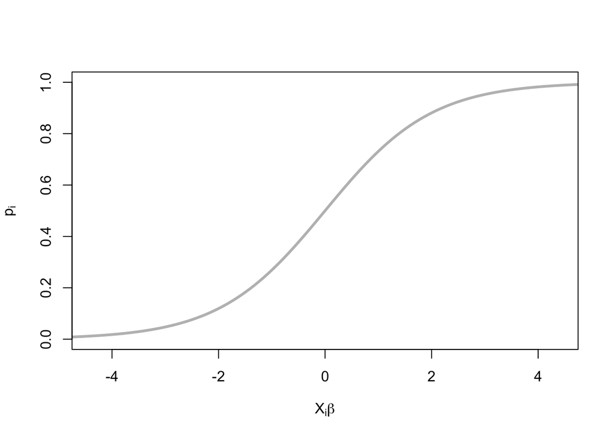

- $X_i^T \beta$ can be negative
- $p_i$ is between 0 and 1.

#### Let’s look at an example…

# Case study: Challenger disaster

## Shuttle data

.pull-left[On January 28, 1986, the Space Shuttle Challenger broke apart 73 seconds into its flight, killing all seven crew members. The spacecraft **disintegrated** over the Atlantic Ocean. The disintegration of the vehicle began after a joint in its right rocket booster failed at liftoff. The failure was caused by the **failure of O-ring seals** used in the joint that were not designed to handle the unusually cold conditions that existed at this launch.]

```r
#.center[<img src="libs/images/w7/Challenger_explosion.jpg" height=250>]
```

We will look at a data set about the number of rubber O-rings showing thermal distress for 23 flights of the space shuttle, with the ambient temperature and pressure at which tests on the putty next to the rings were performed.

## Follow along with the case study

You can follow along with this case study using the template available in the `sta303-bolton/sta303w7` package.

```r
# Only need to download if your didn't for the cheat sheet
# or if your JupyterHub session is new
devtools::install_github("sta303-bolton/sta303w7")

# If it prompts you to update packages,
# just click 'Enter' or 'Return' or input 3
```

Then, go to File -> New File -> R Markdown and choose ‘From template’ and select ‘Challenger case study {sta303w7}’.

Important: If you’re working in the JupyterHub, make sure you save the .Rmd in a subfolder of your Home directory so it doesn’t cause class interactives to fail in future. (Can’t have any .Rmd in your Home directory.)

```r
# install.packages("SMPracticals")
data('shuttle', package='SMPracticals')
rownames(shuttle) = as.character(rownames(shuttle))
shuttle[1:4,]
```

```
##   m r temperature pressure
## 1 6 0          66       50
## 2 6 1          70       50
## 3 6 0          69       50
## 4 6 0          68       50
```

- `m`: number of rings
- `r`: number of damaged rings

Thus we have a situation where we are interested in the number of successes out of a fixed number of trials. Hopefully your memories of the Binomial distribution are being triggered by that language.

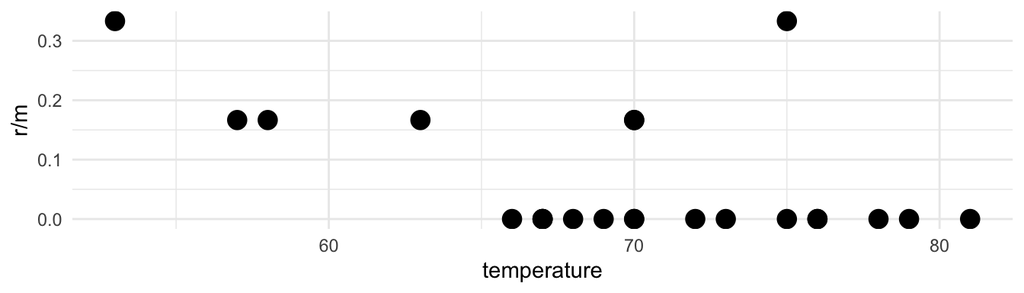

```r
# Base R plot
# plot(shuttle$temperature, shuttle$r/shuttle$m)

# ggplot
shuttle %>%
  ggplot(aes(x = temperature, y = r/m)) +
  geom_point(size = 4) +
  theme_minimal()
```

## Are shuttle rings more likely to get damaged in cold weather?

We can think of **m** as the number of trials, and **r** as the number of “successes”. (It feels weird to call damage a success, but it is our outcome of interest, so we treat it as such.)

.pull-left[
$$\begin{align*}
Y_i \sim & \text{Binomial}(N_i, \mu_i)\\
\log\left(\frac{\mu_i}{1-\mu_i}\right) = & X_i \beta
\end{align*}$$
]

.pull-right[ - m: number of rings, $N_i$ - r: number of damaged rings $Y_i$ - pressure, temperature: covariates $X_i$ - $\mu_i$: probability of a ring becoming damaged given $X_i$ - $\beta_{\text{temperature}}$: parameter of interest]

## Inference: parameter estimation

.pull-left[
$$\begin{align*}
Y_i \sim & G (\mu_i, \theta)\\
h(\mu_i) = & X_i \beta\\
\pi(Y_1 ... Y_N; \beta, \theta) = &
\prod_{i=1}^N f_G (Y_i ; \mu_i, \theta)\\
\log L(\beta, \theta ; y_1 ... y_N) = &
\sum_{i=1}^N \log f_G (y_i; \mu_i, \theta)
\end{align*}$$

- The $Y_i$ are *independently distributed*
- **Joint density** $\pi$ of random variables $(Y_1 ...Y_N)$ is the product of the marginal densities $f_G$.
- **Likelihood function** $L$ given observed data $y_1 ... y_N$ is a function of the parameters.
- **Maximum Likelihood Estimation**:
  $$\hat\beta, \hat\theta = \text{argmax}_{\beta,\theta}L(\beta, \theta ; y_1 \ldots y_N)$$
- The best parameters are those which are most likely to produce the observed data

## Shuttle example in R

- `glm` works like `lm` with a `family` argument.
- Binomial models can take two types of inputs:
  - If, as in this case, we have groups of trials, we need our response to be a matrix with two columns: `y` and `N-y`.
  - If our `y` is a single 0/1 (or otherwise binary categorical variable) then we can set it up as usual, just a single column.

```r
shuttle$notDamaged <- shuttle$m - shuttle$r
shuttle$y <- as.matrix(shuttle[,c('r','notDamaged')])
shuttleFit <- glm(y ~ temperature + pressure,
  family=binomial(link='logit'), data=shuttle)
shuttleFit$coef
```

```
##  (Intercept)  temperature     pressure
##  2.520194641 -0.098296750  0.008484021
```

## Summary of fit

```r
summary(shuttleFit)
```

```
##
## Call:
## glm(formula = y ~ temperature + pressure, family = binomial(link = "logit"),
##     data = shuttle)
##
## Deviance Residuals:
##     Min       1Q   Median       3Q      Max
## -1.0361  -0.6434  -0.5308  -0.1625   2.3418
##
## Coefficients:
##              Estimate Std. Error z value Pr(>|z|)
## (Intercept)  2.520195   3.486784   0.723   0.4698
## temperature -0.098297   0.044890  -2.190   0.0285 *
## pressure     0.008484   0.007677   1.105   0.2691
## ---
## Signif. codes:  0 '***' 0.001 '**' 0.01 '*' 0.05 '.' 0.1 ' ' 1
##
## (Dispersion parameter for binomial family taken to be 1)
##
##     Null deviance: 24.230  on 22  degrees of freedom
## Residual deviance: 16.546  on 20  degrees of freedom
## AIC: 36.106
##
## Number of Fisher Scoring iterations: 5
```

```r
confint(shuttleFit)
```

```
##                    2.5 %      97.5 %
## (Intercept) -4.322926283  9.77264497
## temperature -0.194071699 -0.01356289
## pressure    -0.004346403  0.02885221
```

There is no evidence that pressure is significantly associated with failure of O-rings…but how do we interpret these values?

## Interpreting logistic models

$$\begin{align*}
Y_i \sim & \text{Binomial}(N_i, \mu_i)\\
\log\left(\frac{\mu_i}{1-\mu_i}\right) = & \sum_{p=1}^P X_{ip} \beta_p\\
\left(\frac{\mu_i}{1-\mu_i}\right) = & \prod_{p=1}^P \exp(\beta_p)^{X_{ip}}
\end{align*}$$

- $\mu_i$ is a probability
- $\log[\mu_i / (1-\mu_i)]$ is a log-odds
- $\mu_i / (1-\mu_i)$ is an odds
- If $\mu_i \approx 0$, then $\mu_i \approx \mu_i / (1-\mu_i)$

$$\begin{align*}
\beta_q = &\log\left(\frac{\mu_2}{1-\mu_2}\right) - \log\left(\frac{\mu_1}{1-\mu_1}\right) \\
\exp(\beta_q) = & \left(\frac{\mu_2}{1-\mu_2}\right) \left/ \left(\frac{\mu_1}{1-\mu_1}\right)\right. \\
\end{align*}$$

- $\beta_q$ is the log-odds ratio
- $\exp(\beta_q)$ is the odds ratio
- $\exp(\text{intercept})$ is the baseline odds, when $X_{1} \ldots X_{n} = 0$.

## Centring parameters

```r
quantile(shuttle$temperature)
```

```
##   0%  25%  50%  75% 100%
##   53   67   70   75   81
```

```r
quantile(shuttle$pressure)
```

```
##   0%  25%  50%  75% 100%
##   50   75  200  200  200
```

- Currently the intercept is log-odds when temperature = 0 and pressure = 0
- centre the covariates so the intercept refers to:
  - temperature = 70 (degrees Farenheit)
  - pressure = 200 (pounds per square inch)

```r
shuttle$temperatureC <- shuttle$temperature  - 70
shuttle$pressureC <-  shuttle$pressure - 200
shuttleFit2 <-  glm(y ~ temperatureC + pressureC, family='binomial', data=shuttle)
```

## Shuttle odds parameters

```r
par_table = cbind(est = summary(
  shuttleFit2)$coef[,1],
  confint(shuttleFit2))
rownames(par_table)[1]= "Baseline"
```

```r
round(exp(par_table),3)
```

```
##                est 2.5 % 97.5 %
## Baseline     0.070 0.023  0.155
## temperatureC 0.906 0.824  0.987
## pressureC    1.009 0.996  1.029
```

**Table 1**: MLEs of baseline odds and odds ratios, with 95% confidence intervals.

## Interpreting shuttle parameters

- The odds of a ring being damaged when temperature = 70 and pressure = 200 is 0.0697, which corresponds to a probability of

```r
round(exp(par_table[1,'est']) / (1+exp(par_table[1,'est'])), 3)
```

```
## [1] 0.065
```

- Each degree increase in temperature (in Fahrenheit) decreases the odds of damage by (in percent)

```r
round(100*(1-exp(par_table[2,'est']) ), 3)
```

```
## [1] 9.362
```

## Week 7 learning checklist

The information on the following slides is **not assessed in this course**.

Consider taking a course like STA442 to go deeper!

## Efficient maximization (for your reference only)

- Iteratively Reweighted Least Squares is the ‘classic’ algorithm when $G$ is in the exponential family
- … but GLMs are easy for any density which is differentiable
- The derivatives with respect to $\beta$ are easy to compute with the chain rule
  $$\begin{multline*}
  \frac{\partial}{\partial \beta_p} \log L(\beta, \theta ; y_1 \ldots t_N) = \\
  \sum_{i=1}^N \left[\frac{d}{d \mu} \log f_G (Y_i; \mu, \theta)
  \right]_{\mu = h^{-1}(X_i^T\beta)}
  \left[
  \frac{d}{d \eta}h^{-1}(\eta)
  \right]_{\eta = X_i^T\beta} \cdot X_{ip}
  \end{multline*}$$
- Analytical expressions exist for the derivatives of $\log f_G$ and $h^{-1}$
- Second derivatives are also tractable
- Numerical maximization to find $\hat\beta$ is fast when derivatives are available

## Numerical maximizers (for your reference only)

- There are hundreds of them!
- `optim` is the standard `R` optimizer, which has 6 methods available.
  - some methods will use gradients if you provide them.
- `TrustOptim` uses derivatives and ‘trust regions’, the method used in INLA.
- `ipopt` is probably the cutting edge.
- Statisticians don’t make enough use of of-the-shelf optimizers.

## Automatic differentiation (for your reference only)

$$\sum_{i=1}^N \left[\frac{d}{d \mu} \log f_G (Y_i; \mu, \theta)
\right]_{\mu = h^{-1}(X_i^T\beta)}
\left[
\frac{d}{d \eta}h^{-1}(\eta)
\right]_{\eta = X_i^T\beta} \cdot X_{ip}$$

- Overkill for most GLMs, but infinitely extensible.
- Computers evaluate logs, sines, and other functions through some Taylor-series-like polynomial thing.
- … which are easy to differentiate!
- AD programs can take computer code and figure out how to differentiate it.
- Used in Neural Nets, Hamiltonian MCMC, optimization, and many more.